# NY Shooting Incident Data Analysis

Monica Silva

2026-10-11

## NYPD Shooting Incident Data (Historic)

This is part of the final assignment for `Data Science as Field` course.

The goal is to import, tidy and analyze the NYPD Shooting Incident dataset obtained. It includes every shooting incident that occurred in NYC going back to 2006 through the end of the previous calendar year. Data retrieved from https://catalog.data.gov/dataset/nypd-shooting-incident-data-historic.

This segment of code imports the data in a reproducible manner.

```r
csv_url <- "https://data.cityofnewyork.us/api/v3/views/833y-fsy8/export.csv?accessType=DOWNLOAD"
df <- read_csv(csv_url)
df
```

```
## # A tibble: 29,744 × 21
##    INCIDENT_KEY OCCUR_DATE OCCUR_TIME BORO      LOC_OF_OCCUR_DESC PRECINCT
##           <dbl> <chr>      <time>     <chr>     <chr>                <dbl>
##  1    298699604 12/31/2024 19:16      BROOKLYN  OUTSIDE                 69
##  2    298699604 12/31/2024 19:16      BROOKLYN  OUTSIDE                 69
##  3    298672094 12/30/2024 12:15      BRONX     OUTSIDE                 52
##  4    298672096 12/30/2024 16:45      BRONX     OUTSIDE                 47
##  5    298672096 12/30/2024 16:45      BRONX     OUTSIDE                 47
##  6    298672097 12/30/2024 18:48      BROOKLYN  OUTSIDE                 60
##  7    298672095 12/30/2024 20:32      BRONX     INSIDE                  41
##  8    298672096 12/30/2024 16:45      BRONX     OUTSIDE                 47
##  9    298628071 12/29/2024 17:24      MANHATTAN OUTSIDE                 23
## 10    298628070 12/29/2024 16:21      BRONX     OUTSIDE                 43
## # ℹ 29,734 more rows
## # ℹ 15 more variables: JURISDICTION_CODE <dbl>, LOC_CLASSFCTN_DESC <chr>,
## #   LOCATION_DESC <chr>, STATISTICAL_MURDER_FLAG <lgl>, PERP_AGE_GROUP <chr>,
## #   PERP_SEX <chr>, PERP_RACE <chr>, VIC_AGE_GROUP <chr>, VIC_SEX <chr>,
## #   VIC_RACE <chr>, X_COORD_CD <dbl>, Y_COORD_CD <dbl>, Latitude <dbl>,
## #   Longitude <dbl>, Lon_Lat <chr>
```

## Tidying and Transforming Data

Selecting the columns and transforming into date/factors. This prepares the dataset for following visualizations.

```r
df2 <- df %>% select(c(OCCUR_DATE,OCCUR_TIME,BORO,STATISTICAL_MURDER_FLAG,VIC_SEX,VIC_AGE_GROUP)) %>% mutate(OCCUR_DATE = mdy(OCCUR_DATE), BORO=factor(BORO), VIC_SEX=factor(VIC_SEX), VIC_AGE_GROUP=factor(VIC_AGE_GROUP))
df2$MURDER = as.integer(df2$STATISTICAL_MURDER_FLAG)
df2$OCCUR_TIME <- as.character(df2$OCCUR_TIME)
df2 %>% select(-c(STATISTICAL_MURDER_FLAG))
```

```
## # A tibble: 29,744 × 6
##    OCCUR_DATE OCCUR_TIME BORO      VIC_SEX VIC_AGE_GROUP MURDER
##    <date>     <chr>      <fct>     <fct>   <fct>          <int>
##  1 2024-12-31 19:16:00   BROOKLYN  M       18-24              0
##  2 2024-12-31 19:16:00   BROOKLYN  M       25-44              0
##  3 2024-12-30 12:15:00   BRONX     M       25-44              0
##  4 2024-12-30 16:45:00   BRONX     F       25-44              0
##  5 2024-12-30 16:45:00   BRONX     M       18-24              0
##  6 2024-12-30 18:48:00   BROOKLYN  M       45-64              0
##  7 2024-12-30 20:32:00   BRONX     M       25-44              1
##  8 2024-12-30 16:45:00   BRONX     F       <18                0
##  9 2024-12-29 17:24:00   MANHATTAN M       25-44              0
## 10 2024-12-29 16:21:00   BRONX     M       <18                0
## # ℹ 29,734 more rows
```

```r
summary(df2)
```

```
##    OCCUR_DATE             OCCUR_TIME               BORO
##  Min.   :2006-01-01   Length   :29744   BRONX        : 8834
##  1st Qu.:2009-10-29   N.unique : 1424   BROOKLYN     :11685
##  Median :2014-03-25   N.blank  :    0   MANHATTAN    : 3977
##  Mean   :2014-10-31   Min.nchar:    8   QUEENS       : 4426
##  3rd Qu.:2020-06-29   Max.nchar:    8   STATEN ISLAND:  822
##  Max.   :2024-12-31
##
##  STATISTICAL_MURDER_FLAG VIC_SEX   VIC_AGE_GROUP       MURDER
##  Mode :logical           F: 2891   <18    : 3081   Min.   :0.0000
##  FALSE:23979             M:26841   1022   :    1   1st Qu.:0.0000
##  TRUE :5765              U:   12   18-24  :10677   Median :0.0000
##                                    25-44  :13563   Mean   :0.1938
##                                    45-64  : 2118   3rd Qu.:0.0000
##                                    65+    :  236   Max.   :1.0000
##                                    UNKNOWN:   68
```

## Visualizations and Analysis

Here’s a plot showing the number of shootings and murder per day.

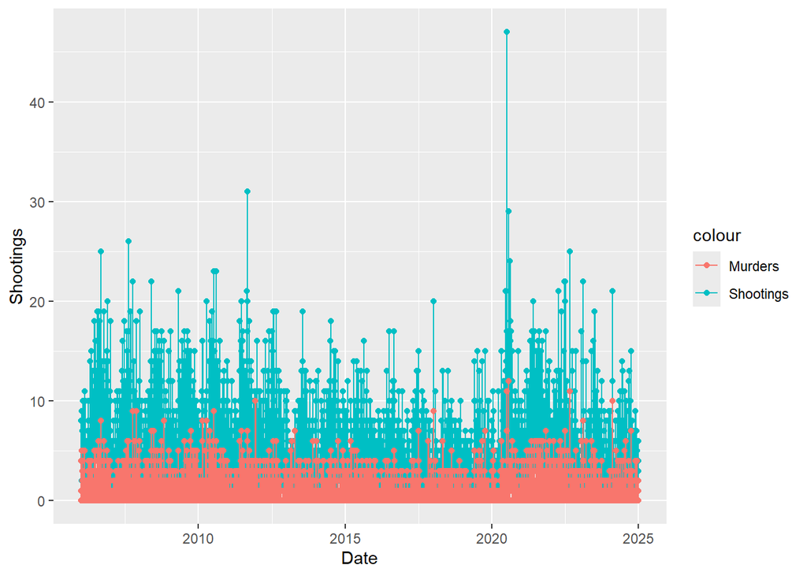

```r
df3 <- df2 %>% group_by(OCCUR_DATE) %>% summarize(Count=n())
df4 <- df2 %>% group_by(OCCUR_DATE) %>% summarize(NUMBER_MURDERS=sum(MURDER))
df5 <- inner_join(df3,df4, by=c("OCCUR_DATE"))
 colnames(df5) <- c("Date","Shootings", "Murders")
df5 %>% ggplot(aes(x=Date, y=Shootings)) + geom_line(aes(color="Shootings")) + geom_point(aes(color="Shootings"))+geom_line(aes(y=Murders,color="Murders")) + geom_point(aes(y=Murders,color="Murders"))
```

Since the previous plot didn’t give much information, here’s a new plot to see cumulative shooting and murders over the years at log scale.

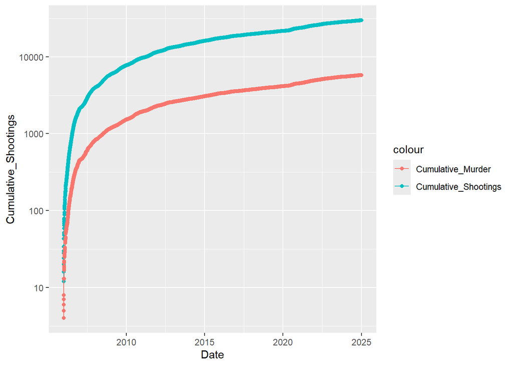

```r
df5 %>% arrange(Date) %>% mutate(Cumulative_Shootings = cumsum(Shootings), Cumulative_Murder =cumsum(Murders)) %>% ggplot(aes(x=Date, y=Cumulative_Shootings)) + geom_line(aes(color="Cumulative_Shootings")) + geom_point(aes(color="Cumulative_Shootings"))+geom_line(aes(y=Cumulative_Murder,color="Cumulative_Murder")) + geom_point(aes(y=Cumulative_Murder,color="Cumulative_Murder"))+scale_y_log10()
```

It seems like both line grow at the same speed. Is that really true? Here’s the same plot without log scale.

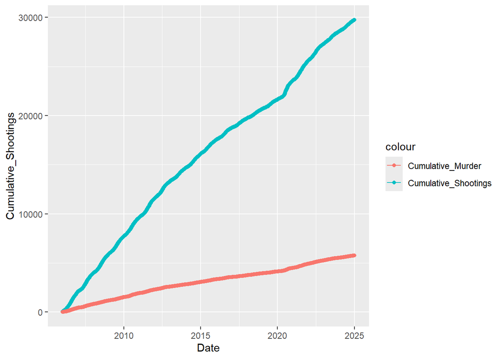

```r
df5 %>% arrange(Date) %>% mutate(Cumulative_Shootings = cumsum(Shootings), Cumulative_Murder =cumsum(Murders)) %>% ggplot(aes(x=Date, y=Cumulative_Shootings)) + geom_line(aes(color="Cumulative_Shootings")) + geom_point(aes(color="Cumulative_Shootings"))+geom_line(aes(y=Cumulative_Murder,color="Cumulative_Murder")) + geom_point(aes(y=Cumulative_Murder,color="Cumulative_Murder"))
```

Here we can see they both grow over time but slightly different rate. We can also see more clearly a slightly increase of both shooting and murders starting 2020 compared to previous plots.

## Simple Modeling data

```r
df6 <- df5 %>% arrange(Date) %>% mutate(Cumulative_Shootings = cumsum(Shootings), Cumulative_Murder =cumsum(Murders))
mod <- lm(Cumulative_Murder ~ Cumulative_Shootings, data=df6)
summary(mod)
```

```
##
## Call:
## lm(formula = Cumulative_Murder ~ Cumulative_Shootings, data = df6)
##
## Residuals:
##     Min      1Q  Median      3Q     Max
## -66.163 -30.455  -1.799  24.978  66.618
##
## Coefficients:
##                       Estimate Std. Error t value Pr(>|t|)
## (Intercept)          4.551e+01  9.064e-01   50.21   <2e-16 ***
## Cumulative_Shootings 1.903e-01  5.070e-05 3753.71   <2e-16 ***
## ---
## Signif. codes:  0 '***' 0.001 '**' 0.01 '*' 0.05 '.' 0.1 ' ' 1
##
## Residual standard error: 34.12 on 6429 degrees of freedom
## Multiple R-squared:  0.9995, Adjusted R-squared:  0.9995
## F-statistic: 1.409e+07 on 1 and 6429 DF,  p-value: < 2.2e-16
```

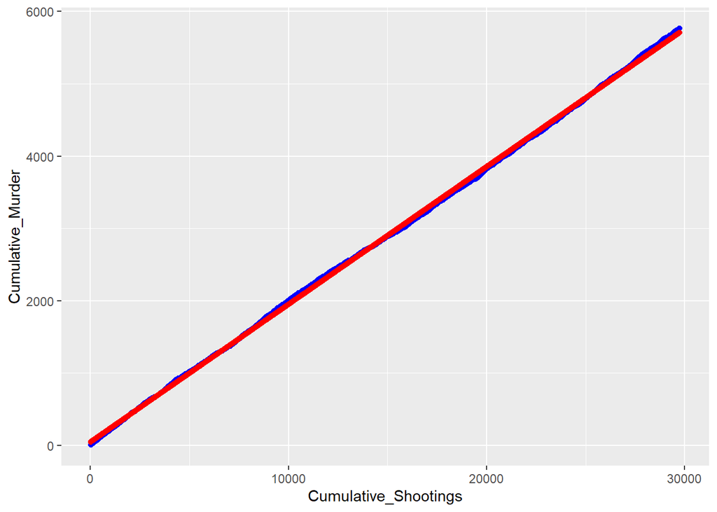

```r
df6 <- df6 %>% mutate(pred=predict(mod))
df6 %>% ggplot() + geom_point(aes(x=Cumulative_Shootings, y=Cumulative_Murder), color="blue") + geom_point(aes(x=Cumulative_Shootings, y=pred), color="red")
```

We can see the model (red) gets a very good prediction on for cumulative murders based on cumulative shootings

## Bias Identification

The source of bias for this dataset might involve data collection. There could have been incidents that were under reported, or how a murder is defined. Is it reported by police as murder, or is it classified as such after a criminal case’s trial is completed and sentenced?

As for personal bias, I’m personally against the right of owning guns by civilians and unnecessary use of force and firepower by the police. I tried to write this report in a object way, avoiding pointing fingers at culprits and ignoring racial, age and sex of both victims and perpetrators.